# Лабораторная работа №5

Tables in LaTeX

Усман Траоре

Российский университет дружбы народов, Москва, Россия

29 декабря 2025

# Цель работы

## Основная цель

Изучить основы создания таблиц в LaTeX, освоить способы выравнивания столбцов, разобраться в требованиях к структуре строк таблицы, а также получить практические навыки использования команды `multicolumn` для объединения ячеек.

## Организация проекта

- использование Windows PowerShell;
- переход в каталог с LaTeX-упражнениями;
- создание отдельной папки `chapter-5-tables`;
- подготовка файлов `exercise-5.14.tex` и `exercise-5.14-final.tex`.

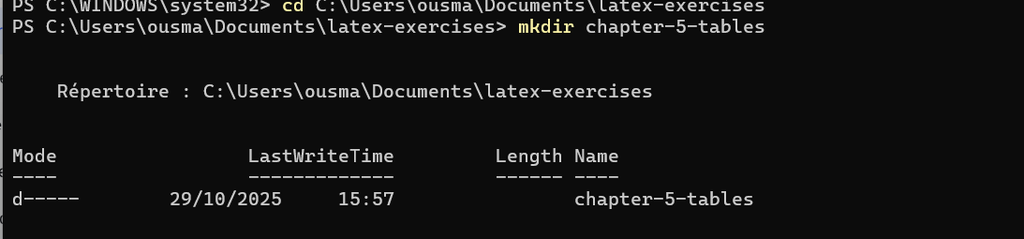

Создание рабочей директории

## Проверка исходного файла

- запуск компиляции с помощью `pdflatex`;
- подключение класса `article`;
- автоматическая загрузка пакета `array`;
- отсутствие ошибок и предупреждений.

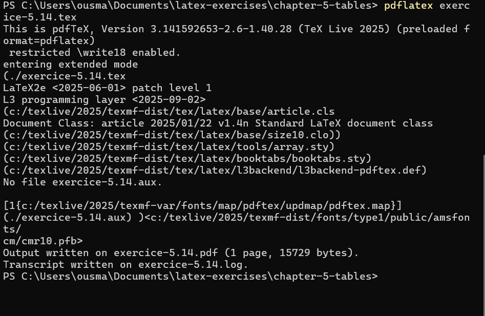

Первый запуск pdflatex

## Начальный пример

- таблица из трёх столбцов: Animal, Food, Size;
- выравнивание по левому краю (`l`);
- корректное отображение данных.

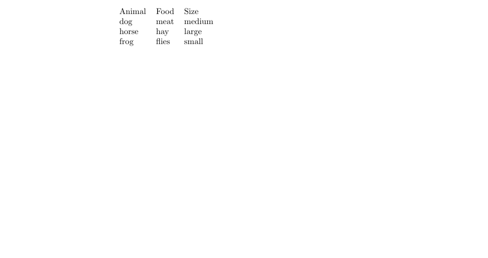

Простейшая таблица

## Обновление документа

- добавление новых примеров таблиц;
- повторная компиляция документа;
- увеличение количества страниц.

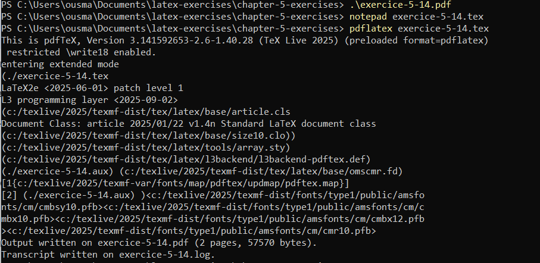

Повторная компиляция

## Типы выравнивания

- `l` — по левому краю;
- `c` — по центру;
- `r` — по правому краю;
- комбинации `l-c-r`, `c-c-c`, `r-l-r`.

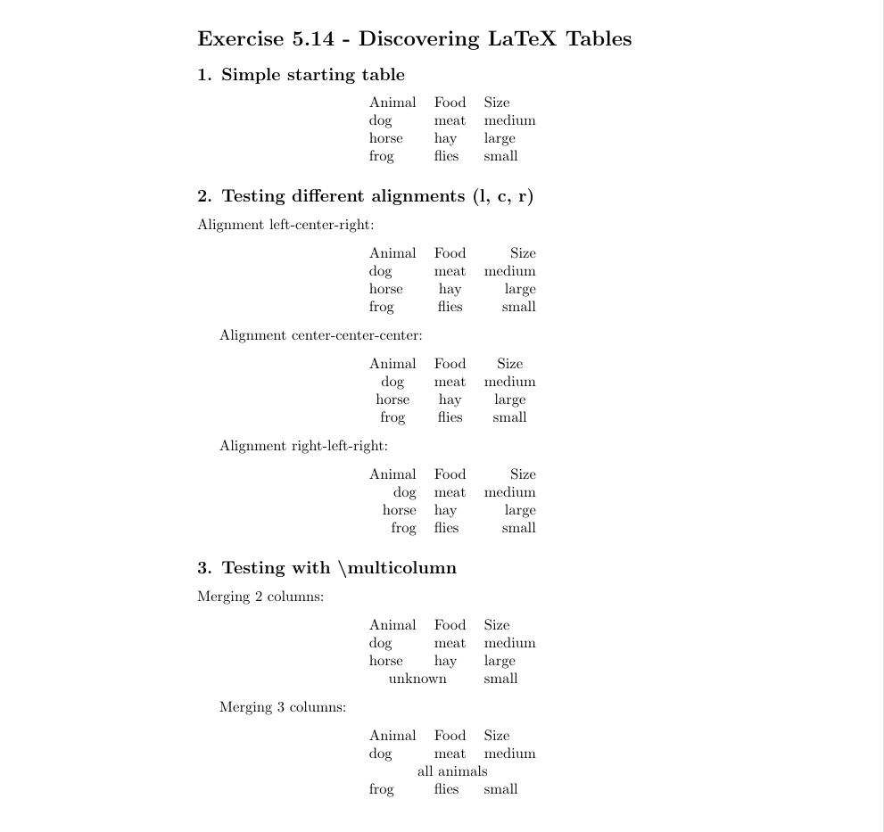

Различные выравнивания столбцов

## Анализ некорректных случаев

- недостаточное количество разделителей `&`;
- избыточное количество элементов в строке;
- ошибки компиляции при нарушении структуры.

**Правило:**  
для таблицы с `N` столбцами каждая строка должна содержать ровно `N−1` символ `&`.

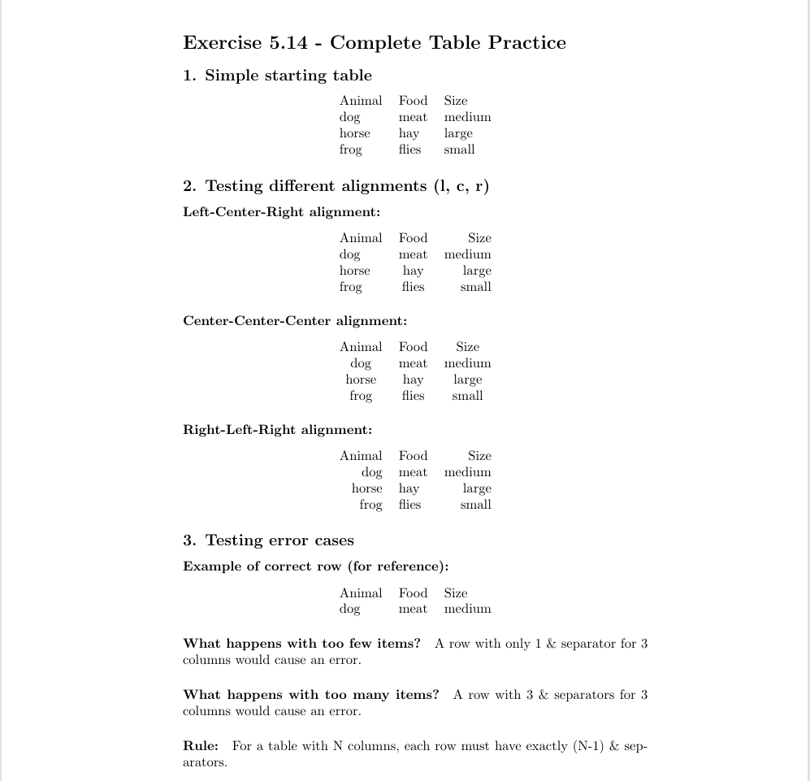

Ошибки в строках таблицы

## Объединение ячеек

- объединение двух столбцов;
- объединение трёх столбцов;
- изменение выравнивания объединённой ячейки;
- сохранение целостности таблицы.

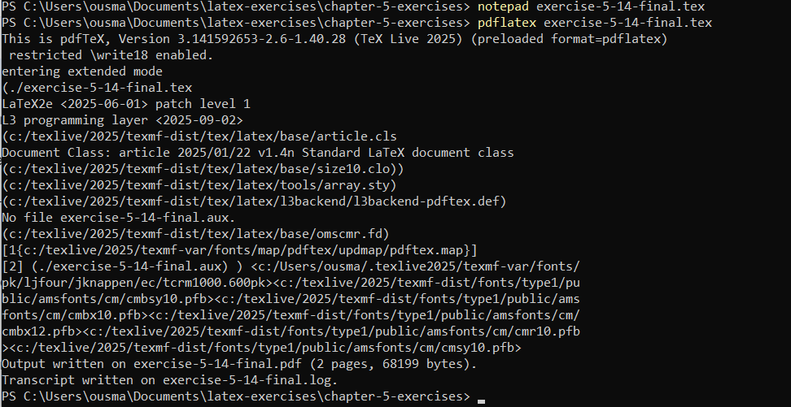

## Итоговый документ

- создание финального TeX-файла;
- успешная компиляция без ошибок;
- корректное отображение всех таблиц.

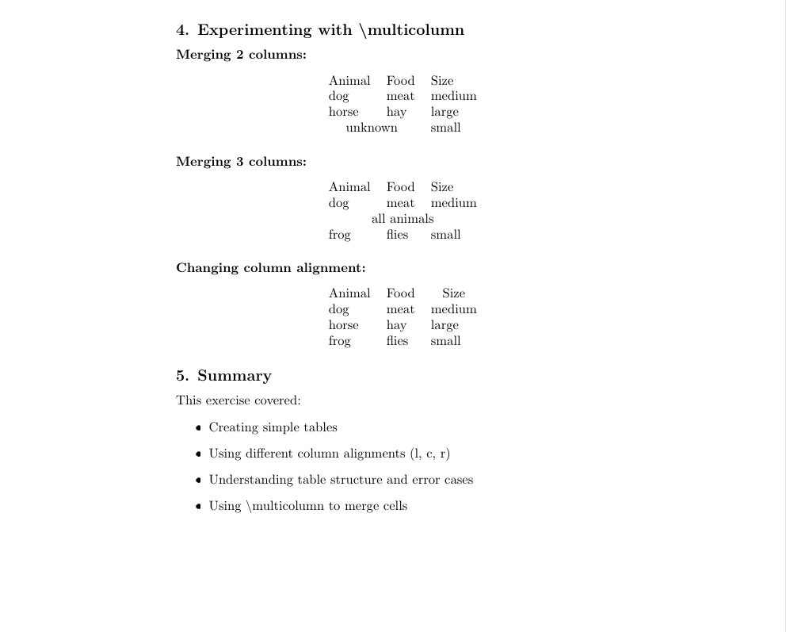

# Итоги работы

## Вывод

В ходе лабораторной работы были изучены базовые приёмы создания и оформления таблиц в LaTeX. Освоены различные типы выравнивания столбцов, рассмотрены типичные ошибки структуры строк и изучена команда `multicolumn`. Полученные навыки позволяют эффективно использовать таблицы при подготовке научных и учебных документов.